# Пример Соноризации Данных.

Соноризация данных это прием, который позволяет направить магию музыки на практические цели познания. Музыка помогает увидеть неочевидные взаимосвязи. По сравнению с графическим отображением, это обстракция более высокого уровня. Ана включает не только зрение, а как показывает нейроинструменталистика все тело человека. Человек "проживает" истину. отсюда во первых, он задействует каналы получения информации, которые раньше молчали. Воспринимает реальность с новой точки зрения. Во-вторых переживает истину эмоционально, что может послужить серьезным тлчком в образовании, так как оно включает воспитательный компонент, в противовес "образовательной услуге".

pandas - это программная библиотека, написанная для языка программирования Python для обработки и анализа данных.

```python
import pandas as pd
```

Matplotlib - это библиотека построения графиков для языка программирования Python и его расширения числовой математики NumPy. Он предоставляет объектно-ориентированный API для встраивания графиков в приложения с использованием наборов инструментов GUI общего назначения, таких как Tkinter, wxPython, Qt или GTK.

```python
import matplotlib.pyplot as plt
```

pyplot - это набор функций, которые заставляют matplotlib работать как MATLAB. Каждая функция pyplot вносит некоторые изменения в фигуру: например, создает фигуру, создает область построения на фигуре, строит некоторые линии в области построения, украшает график метками и т. Д. В matplotlib.

```python
from matplotlib import pyplot
```

```python
all = pd.read_csv('C:/Users/yayar/OneDrive/Documents/текст дисертации Ярочкин/публикации/sonicDataAnalizeYaro/.ipynb_checkpoints/22Data.csv',delimiter=',')
```

**Создаем таблицу дневниковых записей.**

```python
display(all)
```

|  | id | name | age | sex | link | text |
| --- | --- | --- | --- | --- | --- | --- |
| 0 | 1 | Ольга Матюшина | 56 | f | https://prozhito.org/note/448077 | Евгения Михайловна много лет жила в двухэтажно... |
| 1 | 2 | Иван Савиков | 38 | m | https://prozhito.org/note/451514 | И вот 22 июня, когда меня трясла малярия, вдру... |
| 2 | 3 | Лев Пашерстник | 16 | m | https://prozhito.org/note/453306https://prozhi... | Сегодня по радио передавали речь Молотова о пе... |
| 3 | 4 | Андрей Батуев | 33 | m | https://prozhito.org/note/453408https://prozhi... | День ясный, теплый, солнечный. Однако это уже ... |
| 4 | 5 | Янис Гринвалдс | 44 | m | https://prozhito.org/note/461521 | На выставке нас поразила карта Советского Союз... |
| 5 | 6 | Василий Леонтьев | 16 | m | https://prozhito.org/note/461628 | До этого дня много купались. Уже все загорели.... |
| 6 | 7 | Елизавета Турнас | 27 лет | f | https://prozhito.org/note/463884 | 22-го июня с утра пошли с сыном в баню, Вл. Ив... |
| 7 | 8 | Наталия Колесникова | undefined | f | https://prozhito.org/note/466637 | Воскресенье. В ночь с 21 июля на 22 была перва... |
| 8 | 9 | АлександраЗагорская | undefined | f | https://prozhito.org/note/466717 | Началась война с немецкими фашистами. Помню, к... |
| 9 | 10 | Александр Резяпкин | 32 | m | https://prozhito.org/note/467550 | Как только Молотов окончил свою речь, капитан ... |

# Создаем таблицу тонов записей

```python
tone = pd.read_csv('C:/Users/yayar/OneDrive/Documents/текст дисертации Ярочкин/публикации/sonicDataAnalizeYaro/.ipynb_checkpoints/22DataTone.csv',delimiter=',')
```

```python
display(tone)
```

|  | id | start | skip | - | 0 | + |
| --- | --- | --- | --- | --- | --- | --- |
| 0 | 2 | и вот 22 | 0.000000 | 0.000000 | 0.718604 | 0.245095 |
| 1 | 3 | Сегодня по радиоСегодня по радио | 0.000000 | 0.000000 | 0.771854 | 0.222710 |
| 2 | 4 | На выставке | 0.201823 | 0.492198 | 0.000000 | NaN |
| 3 | 5 | День ясный | 0.000000 | 0.256842 | 0.320831 | 0.000000 |
| 4 | 6 | До СССР | 0.000000 | 0.233716 | 0.476590 | 0.000000 |
| 5 | 7 | 22 | 0.000000 | 0.384922 | 0.287778 | 0.000000 |

# создаем простую гистограмму тонов

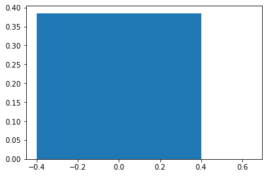

```python
index = tone["+"]
values = tone['-']
plt.bar(index,values)
plt.show()
```

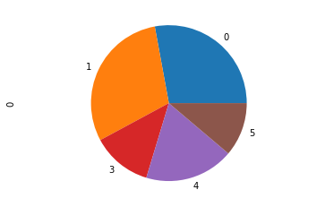

```python
from matplotlib import pyplot

pyplot.axis('equal')
tone['0'].plot(kind='pie')
```

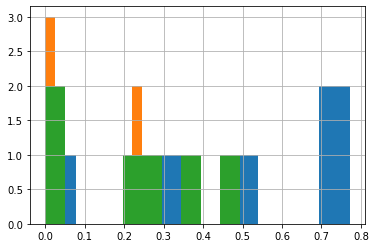

```python
tone['0'].hist()
tone['+'].hist()
tone['-'].hist()
```

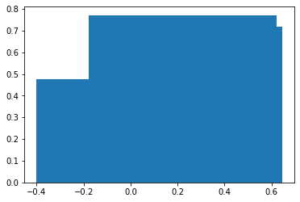

```python
index = tone["+"]
values = tone['0']
plt.bar(index,values)
plt.show()
```

# простая гистограмма до соноризации.

Начинаем соноризацю.

```python
import os
```

```python
os.chdir('..')
```

```python
paper =  pd.read_csv('C:/Users/yayar/OneDrive/Documents/текст дисертации Ярочкин/публикации/sonicHist/22Data.csv',delimiter=',')
```

```python
papper = all[['text']]
```

```python
papper.head()
```

|  | text |
| --- | --- |
| 0 | Евгения Михайловна много лет жила в двухэтажно... |
| 1 | И вот 22 июня, когда меня трясла малярия, вдру... |
| 2 | Сегодня по радио передавали речь Молотова о пе... |
| 3 | День ясный, теплый, солнечный. Однако это уже ... |
| 4 | На выставке нас поразила карта Советского Союз... |

# Делаем более глубокий анализ текста.

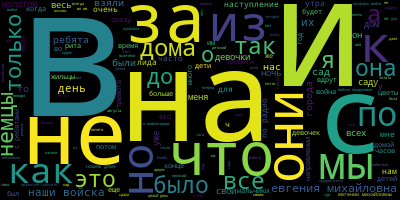

```python
# Import the wordcloud library
from wordcloud import WordCloud
# Join the different processed titles together.
long_string = ','.join(list(papper['text_processed'].values))
# Create a WordCloud object
wordcloud = WordCloud(background_color="black", max_words=5000, contour_width=3, contour_color='steelblue')
# Generate a word cloud
wordcloud.generate(long_string)
# Visualize the word cloud
wordcloud.to_image()
```

Что такое Генсим? Gensim - это бесплатная библиотека Python с открытым исходным кодом для максимально эффективного (с точки зрения компьютера) и безболезненного (с точки зрения человека) представления документов в виде семантических векторов. Алгоритмы Gensim, такие как Word2Vec, FastText, Latent Semantic Indexing (LSI, LSA, LsiModel), Latent Dirichlet Allocation (LDA, LdaModel) и т. Д., Автоматически обнаруживают семантическую структуру документов, исследуя статистические шаблоны совместного появления в корпусе документов. учебные документы. Эти алгоритмы не контролируются, что означает, что вмешательство человека не требуется - вам нужен только корпус текстовых документов. Как только эти статистические шаблоны найдены, любые текстовые документы (предложение, фраза, слово…) можно кратко выразить в новом семантическом представлении и запросить тематическое сходство с другими документами (слова, фразы…).

gensim.corpora Этот модуль реализует концепцию словаря - сопоставление слов и их целочисленных идентификаторов. класс gensim.corpora.dictionary.

```python
import gensim.corpora as corpora
# Create Dictionary
id2word = corpora.Dictionary(data_words)
# Create Corpus
texts = data_words
# Term Document Frequency
corpus = [id2word.doc2bow(text) for text in texts]
# View
print(corpus[:1][0][:30])
```

```
[(0, 3), (1, 1), (2, 1), (3, 1), (4, 1), (5, 1), (6, 1), (7, 1), (8, 2), (9, 1), (10, 1), (11, 1), (12, 1), (13, 2), (14, 1), (15, 1), (16, 1), (17, 1), (18, 1), (19, 1), (20, 1), (21, 1), (22, 1), (23, 1), (24, 1), (25, 1), (26, 1), (27, 1), (28, 1), (29, 1)]
```

Модуль pprint предоставляет возможность «распечатать» произвольные структуры данных Python в форме, которая может использоваться в качестве входных данных для интерпретатора.

```python
from pprint import pprint
# number of topics
num_topics = 10
# Build LDA model
lda_model = gensim.models.LdaMulticore(corpus=corpus,
                                       id2word=id2word,
                                       num_topics=num_topics)
# Print the Keyword in the 10 topics
pprint(lda_model.print_topics())
doc_lda = lda_model[corpus]
```

```
[(0,
  '0.005*"это" + 0.005*"ив" + 0.004*"вл" + 0.004*"дома" + 0.004*"взяли" + '
  '0.004*"наши" + 0.004*"утра" + 0.004*"бежали" + 0.004*"воиска" + '
  '0.003*"воина"'),
 (1,
  '0.005*"дома" + 0.004*"день" + 0.004*"сад" + 0.004*"ребята" + 0.003*"свои" + '
  '0.003*"евгении" + 0.003*"девочки" + 0.003*"это" + 0.003*"лида" + '
  '0.003*"часто"'),
 (2,
  '0.011*"наши" + 0.010*"немцы" + 0.009*"воиска" + 0.006*"ночь" + '
  '0.006*"наступление" + 0.005*"июля" + 0.005*"взяли" + 0.005*"города" + '
  '0.005*"день" + 0.005*"весь"'),
 (3,
  '0.005*"дома" + 0.004*"сад" + 0.003*"саду" + 0.003*"ребята" + 0.003*"день" + '
  '0.003*"евгении" + 0.003*"ночь" + 0.003*"лида" + 0.003*"дом" + '
  '0.003*"воиска"'),
 (4,
  '0.004*"весь" + 0.004*"это" + 0.003*"дома" + 0.003*"утра" + 0.003*"день" + '
  '0.003*"свои" + 0.003*"нам" + 0.003*"ночь" + 0.003*"взяли" + 0.003*"немцы"'),
 (5,
  '0.007*"это" + 0.006*"началась" + 0.006*"воина" + 0.006*"вражеские" + '
  '0.005*"самолеты" + 0.005*"вторглись" + 0.005*"однако" + 0.005*"солнечныи" + '
  '0.005*"дубовои" + 0.005*"боевое"'),
 (6,
  '0.009*"молотов" + 0.005*"воина" + 0.005*"города" + 0.005*"радио" + '
  '0.005*"очень" + 0.005*"людям" + 0.005*"успешна" + 0.004*"день" + '
  '0.004*"несчастье" + 0.004*"родину"'),
 (7,
  '0.006*"радио" + 0.006*"день" + 0.006*"молотов" + 0.005*"сегодня" + '
  '0.005*"это" + 0.004*"ссср" + 0.004*"немцы" + 0.004*"дома" + '
  '0.003*"положении" + 0.003*"прошел"'),
 (8,
  '0.005*"дома" + 0.003*"сад" + 0.003*"наши" + 0.003*"это" + 0.003*"ребята" + '
  '0.003*"воиска" + 0.003*"саду" + 0.003*"дом" + 0.003*"день" + 0.003*"взяли"'),
 (9,
  '0.005*"нам" + 0.005*"алксне" + 0.004*"дома" + 0.004*"часто" + 0.003*"воину" '
  '+ 0.003*"очень" + 0.003*"драгоценных" + 0.003*"воине" + 0.003*"опаснее" + '
  '0.003*"измена"')]
```

# озвучивам данные в программу Super Collider

результы:

github https://github.com/yarov475/sonicHistResearch

soundCloud https://soundcloud.com/yarochkin_sonic